# Activitat 4: Anàlisi de la Variància i Repàs del Curs

Maggi Dicheva Baeva

2025-01-08

# 1 Preprocessat

## 1.1 Variable *Region*

```r
# Carreguem el fitxer

data <- read.csv('Life-Expectancy-Data-Updated.csv')
head(data)
```

```
##      Country                        Region Year Infant_deaths Under_five_deaths
## 1    Turkiye                   Middle East 2015          11.1              13.0
## 2      Spain                European Union 2015           2.7               3.3
## 3      India                          Asia 2007          51.5              67.9
## 4     Guyana                 South America 2006          32.8              40.5
## 5     Israel                   Middle East 2012           3.4               4.3
## 6 Costa Rica Central America and Caribbean 2006           9.8              11.2
##   Adult_mortality Alcohol_consumption Hepatitis_B Measles  BMI Polio Diphtheria
## 1        105.8240                1.32          97      65 27.8    97         97
## 2         57.9025               10.35          97      94 26.0    97         97
## 3        201.0765                1.57          60      35 21.2    67         64
## 4        222.1965                5.68          93      74 25.3    92         93
## 5         57.9510                2.89          97      89 27.0    94         94
## 6         95.2200                4.19          88      86 26.4    89         89
##   Incidents_HIV GDP_per_capita Population_mln Thinness_ten_nineteen_years
```

[output cut: 20 more lines]

```r
# Consultem el tipus de dades

str(data)
```

```
## 'data.frame':    2864 obs. of  21 variables:
##  $ Country                    : chr  "Turkiye" "Spain" "India" "Guyana" ...
##  $ Region                     : chr  "Middle East" "European Union" "Asia" "South America" ...
##  $ Year                       : int  2015 2015 2007 2006 2012 2006 2015 2000 2001 2008 ...
##  $ Infant_deaths              : num  11.1 2.7 51.5 32.8 3.4 9.8 6.6 8.7 22 15.3 ...
##  $ Under_five_deaths          : num  13 3.3 67.9 40.5 4.3 11.2 8.2 10.1 26.1 17.8 ...
##  $ Adult_mortality            : num  105.8 57.9 201.1 222.2 58 ...
##  $ Alcohol_consumption        : num  1.32 10.35 1.57 5.68 2.89 ...
##  $ Hepatitis_B                : int  97 97 60 93 97 88 97 88 97 97 ...
##  $ Measles                    : int  65 94 35 74 89 86 97 99 87 92 ...
##  $ BMI                        : num  27.8 26 21.2 25.3 27 26.4 26.2 25.9 27.9 26.5 ...
##  $ Polio                      : int  97 97 67 92 94 89 97 99 97 96 ...
##  $ Diphtheria                 : int  97 97 64 93 94 89 97 99 99 90 ...
##  $ Incidents_HIV              : num  0.08 0.09 0.13 0.79 0.08 0.16 0.08 0.08 0.13 0.43 ...
##  $ GDP_per_capita             : int  11006 25742 1076 4146 33995 9110 9313 8971 3708 2235 ...
##  $ Population_mln             : num  78.53 46.44 1183.21 0.75 7.91 ...
##  $ Thinness_ten_nineteen_years: num  4.9 0.6 27.1 5.7 1.2 2 2.3 2.3 4 2.9 ...
##  $ Thinness_five_nine_years   : num  4.8 0.5 28 5.5 1.1 1.9 2.3 2.3 3.9 3.1 ...
##  $ Schooling                  : num  7.8 9.7 5 7.9 12.8 7.9 12 10.2 9.6 10.9 ...
##  $ Economy_status_Developed   : int  0 1 0 0 1 0 0 1 0 0 ...
##  $ Economy_status_Developing  : int  1 0 1 1 0 1 1 0 1 1 ...
##  $ Life_expectancy            : num  76.5 82.8 65.4 67 81.7 78.2 71.2 71.2 71.9 68.7 ...
```

Trobo que seria més net treballar amb les variables *Alcohol_consumption* i *Adult_mortality* amb dos decimals en lloc de quatre. Realitzem la transformació.

```r
library(dplyr)
data <- data %>%
  mutate(
    Adult_mortality = round(Adult_mortality, 2),
    Alcohol_consumption = round(Alcohol_consumption, 2)
  )
```

```r
# Canviem les categories de la variable *País*

data <- data %>%
  mutate(
    Region = case_when(
      Region %in% c("European Union", "Rest of Europe") ~ "Europe",
      Region %in% c("South America", "Central America and Caribbean") ~ "South-Central America",
      TRUE ~ Region
    )
  )
head(data)
```

```
##      Country                Region Year Infant_deaths Under_five_deaths
## 1    Turkiye           Middle East 2015          11.1              13.0
## 2      Spain                Europe 2015           2.7               3.3
## 3      India                  Asia 2007          51.5              67.9
## 4     Guyana South-Central America 2006          32.8              40.5
## 5     Israel           Middle East 2012           3.4               4.3
## 6 Costa Rica South-Central America 2006           9.8              11.2
##   Adult_mortality Alcohol_consumption Hepatitis_B Measles  BMI Polio Diphtheria
## 1          105.82                1.32          97      65 27.8    97         97
## 2           57.90               10.35          97      94 26.0    97         97
## 3          201.08                1.57          60      35 21.2    67         64
## 4          222.20                5.68          93      74 25.3    92         93
## 5           57.95                2.89          97      89 27.0    94         94
## 6           95.22                4.19          88      86 26.4    89         89
##   Incidents_HIV GDP_per_capita Population_mln Thinness_ten_nineteen_years
```

[output cut: 20 more lines]

## 1.2 Variable *Life-Expectancy*

Per detectar possibles valors atípics, primer generem un boxplot amb la variable Life-Expectancy

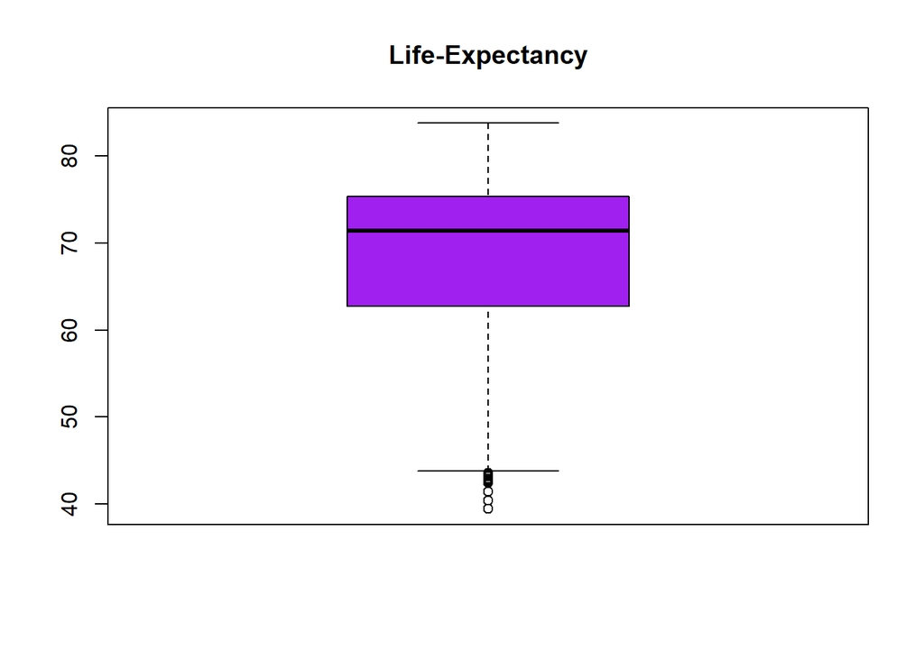

```r
boxplot(data$Life_expectancy, main = "Life-Expectancy", col = "purple")
```

A partir de la visualització, observem que hi ha valors atípics en edats més baixes, és a dir, que aparentment hi ha països en les que l’esperança de vida és atípicament més baixa.

```r
# Extreiem els valors atípics de la variable amb el rang interquartílic (IQR)
Q1 <- quantile(data$Life_expectancy, 0.25)
Q3 <- quantile(data$Life_expectancy, 0.75)
IQR <- Q3 - Q1
lower_limit <- Q1 - 1.5 * IQR
upper_limit <- Q3 + 1.5 * IQR

life_expectancy_outliers <- data %>%
  filter(Life_expectancy < lower_limit | Life_expectancy > upper_limit) %>%
  select(Country, Region, Year, Life_expectancy) %>%
  arrange(Country, Year)

# Mostrem la taula de valors atípics amb les variables demanades
print(life_expectancy_outliers)
```

```
##         Country Region Year Life_expectancy
## 1      Eswatini Africa 2003            43.4
## 2      Eswatini Africa 2004            42.7
## 3      Eswatini Africa 2005            42.5
## 4      Eswatini Africa 2006            42.7
## 5      Eswatini Africa 2007            43.3
## 6       Lesotho Africa 2004            43.1
## 7       Lesotho Africa 2005            42.7
## 8       Lesotho Africa 2006            42.6
## 9       Lesotho Africa 2007            42.9
## 10      Lesotho Africa 2008            43.4
## 11 Sierra Leone Africa 2000            39.4
## 12 Sierra Leone Africa 2001            40.4
## 13 Sierra Leone Africa 2002            41.4
## 14 Sierra Leone Africa 2003            42.4
## 15 Sierra Leone Africa 2004            43.5
## 16     Zimbabwe Africa 2002            43.5
## 17     Zimbabwe Africa 2003            43.2
## 18     Zimbabwe Africa 2004            43.1
## 19     Zimbabwe Africa 2005            43.2
```

En un principi, a mi aquests valors em semblen atípics, però no erronis. Veig possible que en alguns països l’esperança de vida fos tan baixa com s’indica per diferents factors ambientals. A més, són bastant consistents al llarg dels anys, no varien molt. Per tant, no veig necessari substituir-los per valors perduts (NA).

## 1.3 Valors perduts

Comprovem si hi ha algun valor perdut en el dataframe

```r
sum(is.na(data))
```

```
## [1] 0
```

No és el nostre cas, així que no prenem cap mesura.

## 1.4 Subconjunt de dades. Anàlisi de l’any 2015

Creem el subconjunt que farem servir d’aquí en endavant

```r
data_2015 <- data %>%
  filter(Year == 2015)
head(data_2015)
```

```
##              Country      Region Year Infant_deaths Under_five_deaths
## 1            Turkiye Middle East 2015          11.1              13.0
## 2              Spain      Europe 2015           2.7               3.3
## 3 Russian Federation      Europe 2015           6.6               8.2
## 4           Cameroon      Africa 2015          57.0              88.0
## 5        Gambia, The      Africa 2015          39.7              59.8
## 6            Algeria      Africa 2015          21.6              25.2
##   Adult_mortality Alcohol_consumption Hepatitis_B Measles  BMI Polio Diphtheria
## 1          105.82                1.32          97      65 27.8    97         97
## 2           57.90               10.35          97      94 26.0    97         97
## 3          223.00                8.06          97      97 26.2    97         97
## 4          340.13                4.55          84      64 24.3    77         84
## 5          261.71                2.69          97      64 23.9    96         97
## 6           95.82                0.55          95      99 25.5    95         95
##   Incidents_HIV GDP_per_capita Population_mln Thinness_ten_nineteen_years
```

[output cut: 20 more lines]

Ja ho tenim tot llest per continuar amb l’anàlisi.

# 2 Estadística descriptiva

## 2.1 Esperança de vida per regió

Dibuixem els boxplots de la variable *Life-expectancy* per regions

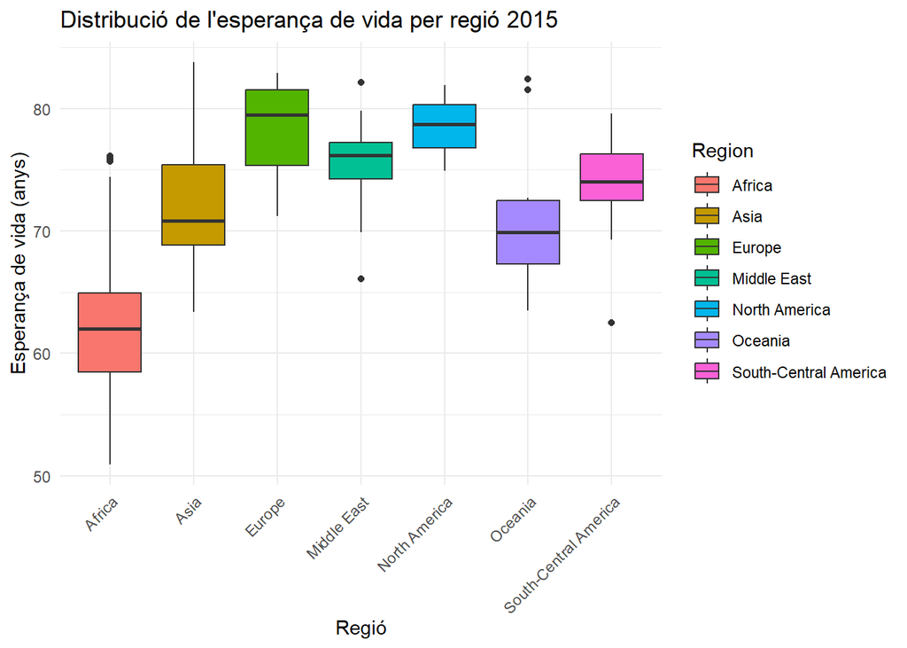

```r
library(ggplot2)

ggplot(data_2015, aes(x = Region, y = Life_expectancy, fill = Region)) +
  geom_boxplot() +
  theme_minimal() +
  labs(title = "Distribució de l'esperança de vida per regió 2015",
       x = "Regió",
       y = "Esperança de vida (anys)") +
  theme(axis.text.x = element_text(angle = 45, hjust = 1))
```

Veiem que hi ha regions que tenen alguns valors atípics (Àfrica, Orient Pròxim, Oceania i América).

## 2.2 Correlació

```r
numeric_vars <- data %>%
  select(Infant_deaths, Under_five_deaths, Adult_mortality, Alcohol_consumption,
         GDP_per_capita, Population_mln, Thinness_ten_nineteen_years, Thinness_five_nine_years,
         Schooling, Life_expectancy, Hepatitis_B, Measles, Polio, Diphtheria)

# Calculem la matriu de correlació
cor_matrix <- cor(numeric_vars)
round_cor_matrix <- round(cor_matrix, 3)

print(round_cor_matrix)
```

```
##                             Infant_deaths Under_five_deaths Adult_mortality
## Infant_deaths                       1.000             0.986           0.795
## Under_five_deaths                   0.986             1.000           0.802
## Adult_mortality                     0.795             0.802           1.000
## Alcohol_consumption                -0.455            -0.409          -0.245
## GDP_per_capita                     -0.512            -0.470          -0.510
## Population_mln                      0.008            -0.005          -0.054
## Thinness_ten_nineteen_years         0.491             0.467           0.382
## Thinness_five_nine_years            0.478             0.451           0.380
## Schooling                          -0.789            -0.773          -0.581
## Life_expectancy                    -0.920            -0.920          -0.945
## Hepatitis_B                        -0.513            -0.507          -0.345
## Measles                            -0.526            -0.513          -0.416
## Polio                              -0.741            -0.743          -0.524
## Diphtheria                         -0.722            -0.725          -0.514
##                             Alcohol_consumption GDP_per_capita Population_mln
## Infant_deaths                            -0.455         -0.512          0.008
## Under_five_deaths                        -0.409         -0.470         -0.005
## Adult_mortality                          -0.245         -0.510         -0.054
## Alcohol_consumption                       1.000          0.444         -0.039
## GDP_per_capita                            0.444          1.000         -0.041
## Population_mln                           -0.039         -0.041          1.000
## Thinness_ten_nineteen_years              -0.446         -0.375          0.256
## Thinness_five_nine_years                 -0.433         -0.381          0.258
## Schooling                                 0.616          0.581         -0.034
## Life_expectancy                           0.399          0.583          0.026
## Hepatitis_B                               0.168          0.159         -0.082
## Measles                                   0.319          0.314         -0.098
## Polio                                     0.302          0.314         -0.033
## Diphtheria                                0.299          0.313         -0.027
##                             Thinness_ten_nineteen_years
## Infant_deaths                                     0.491
## Under_five_deaths                                 0.467
## Adult_mortality                                   0.382
## Alcohol_consumption                              -0.446
## GDP_per_capita                                   -0.375
## Population_mln                                    0.256
## Thinness_ten_nineteen_years                       1.000
## Thinness_five_nine_years                          0.939
## Schooling                                        -0.571
```

[output cut: 20 more lines]

```
##                             Hepatitis_B Measles  Polio Diphtheria
## Infant_deaths                    -0.513  -0.526 -0.741     -0.722
## Under_five_deaths                -0.507  -0.513 -0.743     -0.725
## Adult_mortality                  -0.345  -0.416 -0.524     -0.514
## Alcohol_consumption               0.168   0.319  0.302      0.299
## GDP_per_capita                    0.159   0.314  0.314      0.313
## Population_mln                   -0.082  -0.098 -0.033     -0.027
## Thinness_ten_nineteen_years      -0.208  -0.341 -0.313     -0.304
## Thinness_five_nine_years         -0.214  -0.367 -0.307     -0.296
## Schooling                         0.348   0.498  0.553      0.536
## Life_expectancy                   0.418   0.490  0.641      0.628
## Hepatitis_B                       1.000   0.429  0.724      0.762
## Measles                           0.429   1.000  0.514      0.494
## Polio                             0.724   0.514  1.000      0.953
## Diphtheria                        0.762   0.494  0.953      1.000
```

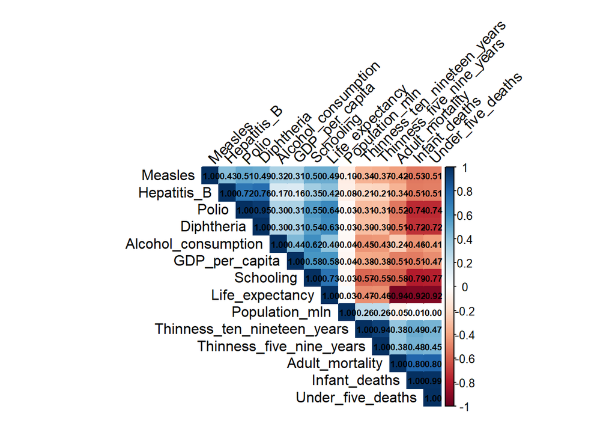

```r
# Mostrem la gràfica de la matriu de correlació
library(corrplot)
corrplot(round_cor_matrix, method = "color", type = "upper", order = "hclust",
         tl.col = "black", tl.srt = 45,
         addCoef.col = "black",
         number.cex = 0.6)
```

A partir de la matriu i la gràfica de correlació, podem extreure:

- Les variables *Infant_deaths*, *Under_five_deaths* i *Adult_mortality* mostren una correlació molt negativa amb l’esperança de vida (-0.920, -0.920 i -0.945, respectivament), indicant que les altes taxes de mortalitat infantil, infantil per sota dels 5 anys i adulta estan fortament associades amb una menor esperança de vida.
- La variable *GDP_per_capita* té una correlació positiva notable (0.583) amb l’esperança de vida, reflectint que un major desenvolupament econòmic pot contribuir a una millor salut i una vida més llarga.
- La variable *Schooling* presenta una correlació positiva significativa (0.732) amb l’esperança de vida, suggerint que majors nivells d’educació estan associats amb una esperança de vida més alta.
- Les variables *Polio* i *Diphtheria* mostren una correlació positiva significativa (0.641 i 0.628, respectivament). Això indica que una major cobertura de vacunació contra la polio i la diftèria està associada amb una millor esperança de vida.

## 2.3 Coordenades paral·leles

Primer, calculem la mirjana de cadascuna de les variables objectiu.

```r
data_means <- data_2015 %>%
  group_by(Region) %>%
  summarise(
    Thinness_five_nine_years = mean(Thinness_five_nine_years),
    Schooling = mean(Schooling),
    Alcohol_consumption = mean(Alcohol_consumption),
    Life_expectancy = mean(Life_expectancy)
  )

print(data_means)
```

```
## # A tibble: 7 × 5
##   Region    Thinness_five_nine_y…¹ Schooling Alcohol_consumption Life_expectancy
##   <chr>                      <dbl>     <dbl>               <dbl>           <dbl>
## 1 Africa                     6.57       5.26               2.99             62.5
## 2 Asia                       8.91       8.10               2.79             72.0
## 3 Europe                     1.45      11.7                9.11             78.4
## 4 Middle E…                  5.86       8.56               0.791            75.3
## 5 North Am…                  0.867     11.7                7.01             78.5
## 6 Oceania                    1.83       8.58               2.68             71.2
## 7 South-Ce…                  2.61       8.66               5.63             74.1
## # ℹ abbreviated name: ¹Thinness_five_nine_years
```

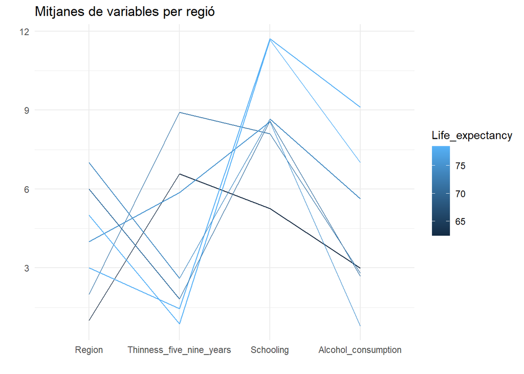

```r
# Info extreta de https://r-graph-gallery.com/parallel-plot-ggally.html
install.packages("GGally")
library(GGally)
ggparcoord(data_means,
           columns = 1:4,
           groupColumn = 5,
           scale = "globalminmax",
           title = "Mitjanes de variables per regió") +
  theme_minimal() +
  labs(x = "",
       y = "")
```

# 3 Estadística inferencial

**Considerant un nivell de confiança del 99%:**

## 3.1 Hipòtesi de contrast

Per aquesta anàlisi, definirem les hipòtesis nul·la i alternativa de la següent manera:

- **Hipòtesi Nul·la (H0)**: L’esperança de vida mitjana a l’Àfrica és igual o superior a la mitjana de la resta dels països. H0: μ Àfrica ≥ μ Resta
- **Hipòtesi Alternativa (H1)**: L’esperança de vida mitjana a l’Àfrica és inferior a la mitjana de la resta dels països. H1: μ Àfrica < μ Resta

## 3.2 Test

El test més adequat per aquesta comparació, considerant que estem comparant les mitjanes de dues poblacions independents, és el test t per a dues mostres independents.

## 3.3 Contrast

```r
library(dplyr)
life_expectancy_africa <- data_2015 %>%
  filter(Region == "Africa") %>%
  pull(Life_expectancy)

life_expectancy_rest <- data_2015 %>%
  filter(Region != "Africa") %>%
  pull(Life_expectancy)
```

Realitzem un test t de Welch (que no assumeix variàncies iguals) per comparar les mitjanes de l’esperança de vida.

```r
welch_test <- t.test(life_expectancy_africa, life_expectancy_rest, alternative = "less", conf.level = 0.99)
print(welch_test)
```

```
##
##  Welch Two Sample t-test
##
## data:  life_expectancy_africa and life_expectancy_rest
## t = -12.602, df = 74.699, p-value < 2.2e-16
## alternative hypothesis: true difference in means is less than 0
## 99 percent confidence interval:
##       -Inf -10.20836
## sample estimates:
## mean of x mean of y
##  62.46667  75.04844
```

## 3.4 Interpretació

El test t de Welch mostra una diferència estadísticament significativa en l’esperança de vida entre Àfrica i la resta del món, amb un valor p pràcticament nul (< 2.2e-16) i un estadístic de contrast molt negatiu (t = -12.602). Per tant, rebutjem la hipòtesi nul·la.

Això indica que l’esperança de vida a Àfrica és significativament inferior a la de la resta del món, amb una diferència mitjana estimada de 12.58 anys (75.05 - 62.47).